# Bordeaux Wine Reviewer

Shivam Patel, Ethan Gruis, Ben Siglow

10/29/2020

# Load Packages

```r
##install.packages("SHAPforxgboost")
#install_github("AppliedDataSciencePartners/xgboostExplainer")
library(devtools)
library(xgboostExplainer)
library(tidyverse)
library(ggdark)
library(rattle)
library(RColorBrewer)
library(randomForest)
library(caTools)
library(caret)
library(rpart)
library(splitstackshape)
library(xgboost)
library(Metrics)
library(pROC)
library(SHAPforxgboost)
library(xgboostExplainer)
source("a_insights_shap_functions.r")
```

# Data Cleaning and Exploration

## Loading Data

```r
link <- 'https://www.dropbox.com/s/mjj5x2n2wfjxqs9/BordeauxWines.csv?dl=1'
wine_data <- read_csv(link, locale = readr::locale(encoding = "latin1"))
# Commented out formatting purposes, prior data review/exploration
# summary(wine_data)
# str(wine_data)
```

## Mutate our variables into factors & remove variables with constant values

```r
wine_cols <- c(5:989)
wine_data[,wine_cols] <- lapply(wine_data[,wine_cols], factor)

# ISSUE: when factorized, wine sometimes has columns with only 1 factor, this selects only columns with multiple factors and drops the rest
wine_fixed <- wine_data[, sapply(wine_data, function(col) length(unique(col))) > 1]
```

## Remove dollar signs from Price.

```r
# Fix Price Variable
wine_fixed$Price <- str_replace(wine_fixed$Price, "\\$", "")

wine_fixed$Price <- as.numeric(wine_fixed$Price)
# Creating no price dataframe without dropping NAs
noprice_wine_fixed <- wine_fixed

wine_fixed <- drop_na(wine_fixed)

# Fix ColNames
colnames(wine_fixed) <- make.names(names(wine_fixed))

# For some reason there are two WELL DONE columns, so lets change the name of one of them?
colnames(wine_fixed)[489] <- 'WELL.DONE.2'
```

# Visualizations

```r
# Score v Price
price_score_plot <- ggplot(wine_fixed, aes(x = Price, y = Score)) +
  geom_point() +
  geom_smooth(method = "lm", color = "red") +
  theme_bw() +
  theme(panel.grid.major = element_blank(), # Turn of the background grid
    panel.grid.minor = element_blank(),
    panel.background = element_blank()) +
  dark_theme_gray()
```

```
## Inverted geom defaults of fill and color/colour.
## To change them back, use invert_geom_defaults().
```

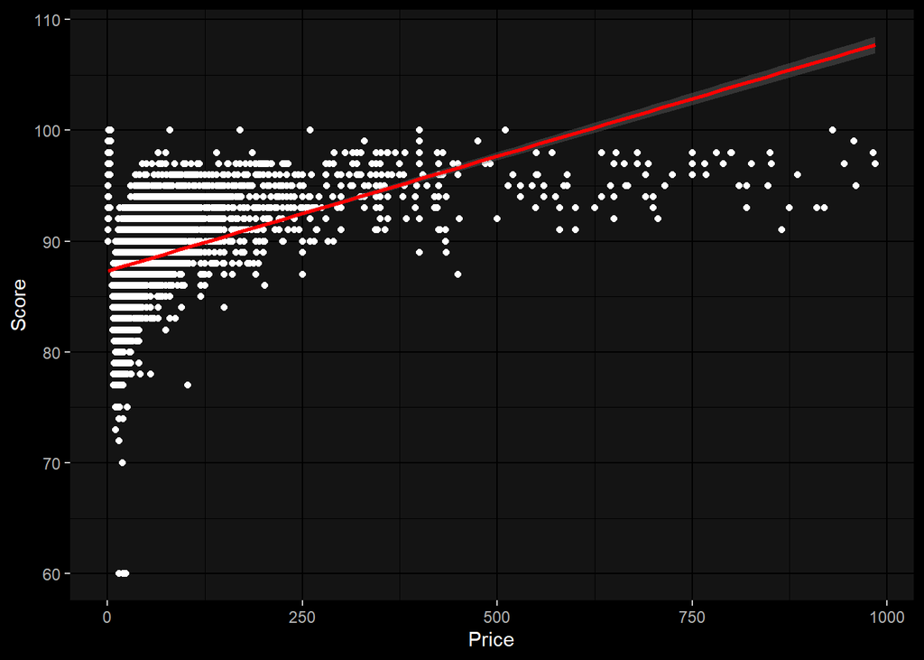

```r
price_score_plot
```

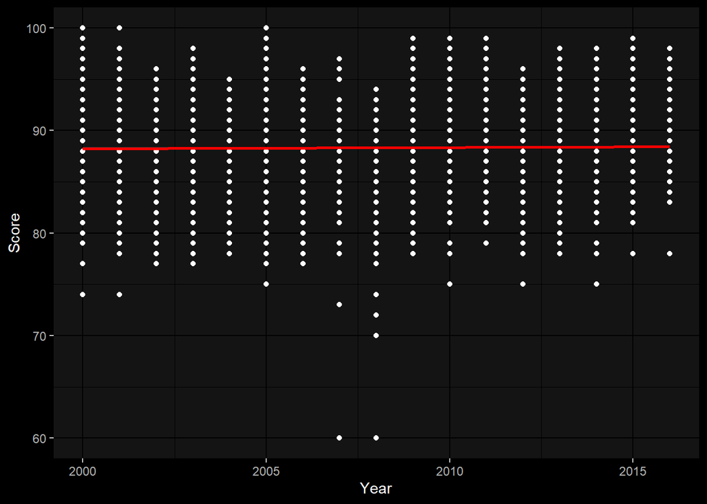

```r
# Score v Year
score_year_plot <- ggplot(wine_fixed, aes(x = Year, y = Score)) +
  geom_point() +
  geom_smooth(method = "lm", color = "red") +
  theme_bw() +
  theme(panel.grid.major = element_blank(), # Turn of the background grid
    panel.grid.minor = element_blank(),
    panel.background = element_blank()) +
  dark_theme_gray()

score_year_plot
```

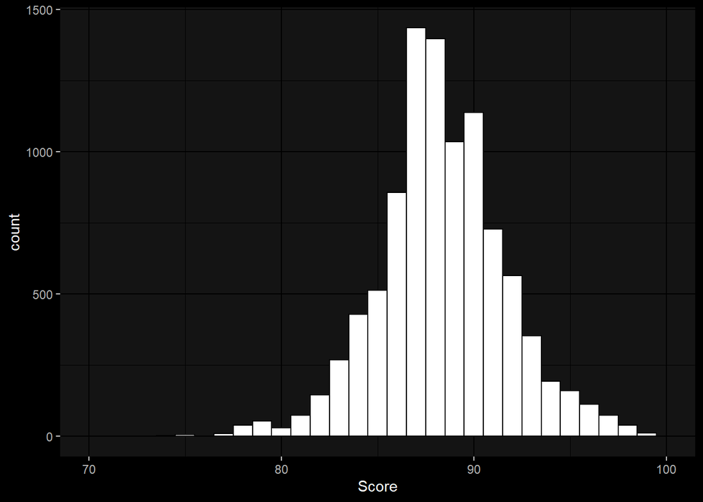

```r
# Score Histogram
hist_score_plot <- ggplot(wine_fixed, aes(x = Score)) +
  geom_histogram(binwidth = 1, color="black", fill="white") +
  theme(panel.grid.major = element_blank(), # Turn of the background grid
    panel.grid.minor = element_blank(),
    panel.background = element_blank()) +
  xlim(70, 100) +
  dark_theme_gray()

hist_score_plot
```

# Linear regressions

```r
# LM 1 = Score predicted by Price
lm_1 <- lm(Score ~ Price, data = wine_fixed)

summary(lm_1)
```

```
##
## Call:
## lm(formula = Score ~ Price, data = wine_fixed)
##
## Residuals:
##      Min       1Q   Median       3Q      Max
## -27.8140  -1.6276   0.1031   1.9582  12.6416
##
## Coefficients:
##              Estimate Std. Error t value Pr(>|t|)
## (Intercept) 8.732e+01  3.638e-02 2399.93   <2e-16 ***
## Price       2.071e-02  3.951e-04   52.42   <2e-16 ***
## ---
## Signif. codes:  0 '***' 0.001 '**' 0.01 '*' 0.05 '.' 0.1 ' ' 1
##
## Residual standard error: 3.015 on 9684 degrees of freedom
## Multiple R-squared:  0.2211, Adjusted R-squared:  0.221
## F-statistic:  2748 on 1 and 9684 DF,  p-value: < 2.2e-16
```

```r
# LM 2 = Score predicted by Year
lm_2 <- lm(Score ~ Year, data = wine_fixed)

summary(lm_2)
```

```
##
## Call:
## lm(formula = Score ~ Year, data = wine_fixed)
##
## Residuals:
##      Min       1Q   Median       3Q      Max
## -28.3289  -2.2278  -0.3289   1.7343  11.7722
##
## Coefficients:
##              Estimate Std. Error t value Pr(>|t|)
## (Intercept) 62.957905  15.519844   4.057 5.02e-05 ***
## Year         0.012635   0.007724   1.636    0.102
## ---
## Signif. codes:  0 '***' 0.001 '**' 0.01 '*' 0.05 '.' 0.1 ' ' 1
##
## Residual standard error: 3.416 on 9684 degrees of freedom
## Multiple R-squared:  0.0002762,  Adjusted R-squared:  0.000173
## F-statistic: 2.676 on 1 and 9684 DF,  p-value: 0.1019
```

# Decision Tree

## Stratified split to the train/test

```r
set.seed(1984)

wine_no_name <- wine_fixed[2:620]

split <-  stratified(wine_no_name, c('Score'), .80,bothSets = TRUE)
train_strat <- split[[1]]
test_strat <- split[[2]]
```

## Run Decision Tree

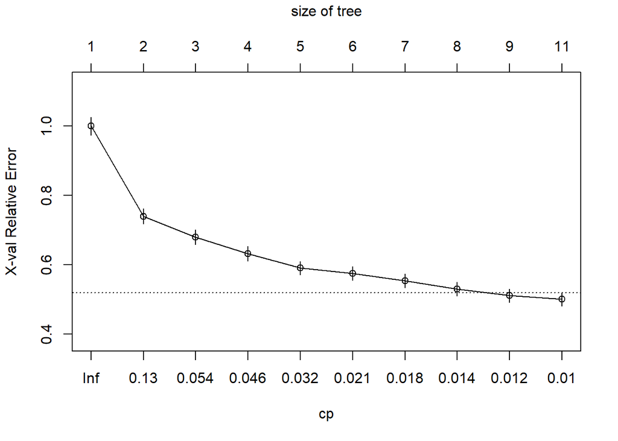

```r
tree_1 <- rpart(Score ~.,
                data = train_strat)

plotcp(tree_1)
```

```r
summary(tree_1)
```

```
## Call:
## rpart(formula = Score ~ ., data = train_strat)
##   n= 7748
##
##            CP nsplit rel error    xerror       xstd
## 1  0.26063852      0 1.0000000 1.0001127 0.02589383
## 2  0.06112550      1 0.7393615 0.7399738 0.02198520
## 3  0.04735141      2 0.6782360 0.6797984 0.02155117
## 4  0.04518660      3 0.6308846 0.6320251 0.02111027
## 5  0.02232117      4 0.5856980 0.5903698 0.01983713
## 6  0.02040546      5 0.5633768 0.5750061 0.01976028
## 7  0.01550915      6 0.5429713 0.5538607 0.01968577
## 8  0.01321119      7 0.5274622 0.5299115 0.01963471
## 9  0.01026553      8 0.5142510 0.5110285 0.01947389
## 10 0.01000000     10 0.4937199 0.5006347 0.01933175
##
## Variable importance
##          Price          GREAT           LONG  MEDIUM.BODIED         BEAUTY
##             67              9              5              3              2
##    FULL.BODIED            FIG           Year          DENSE       STUNNING
##              2              1              1              1              1
##     REMARKABLE TANNINS_MEDIUM          POWER      BEGUILING       RIVETING
##              1              1              1              1              1
##
## Node number 1: 7748 observations,    complexity param=0.2606385
##   mean=88.34602, MSE=11.6757
##   left son=2 (5053 obs) right son=3 (2695 obs)
##   Primary splits:
##       Price       < 38.5   to the left,  improve=0.26063850, (0 missing)
##       GREAT       splits as  LR,         improve=0.19231810, (0 missing)
##       LONG        splits as  LR,         improve=0.10766800, (0 missing)
##       FULL.BODIED splits as  LR,         improve=0.05601591, (0 missing)
##       BLACKBERRY  splits as  LR,         improve=0.05428022, (0 missing)
##   Surrogate splits:
##       LONG   splits as  LR, agree=0.679, adj=0.076, (0 split)
##       GREAT  splits as  LR, agree=0.675, adj=0.065, (0 split)
##       BEAUTY splits as  LR, agree=0.667, adj=0.042, (0 split)
##       FIG    splits as  LR, agree=0.664, adj=0.035, (0 split)
##       DENSE  splits as  LR, agree=0.663, adj=0.032, (0 split)
##
```

[output cut: 161 more lines]

```
##       TANNINS_MEDIUM splits as  LR,         agree=0.746, adj=0.116, (0 split)
##       TANNINS_LOW    splits as  LR,         agree=0.740, adj=0.094, (0 split)
##       TANNINS_HIGH   splits as  LR,         agree=0.736, adj=0.083, (0 split)
##
## Node number 26: 118 observations
##   mean=87.44915, MSE=2.806737
##
## Node number 27: 1001 observations
##   mean=91.09491, MSE=4.237746
##
## Node number 42: 1262 observations
##   mean=87.54913, MSE=5.009868
##
## Node number 43: 509 observations
##   mean=89.37721, MSE=3.81449
```

## Prediction of Tree

```r
wine_pred_no_name <- predict(tree_1, test_strat)

actual <- test_strat$Score
predicted <- wine_pred_no_name
rmse(actual, predicted)
```

```
## [1] 2.410992
```

# Random Forest

## Random Forest Model Results

```r
load("./random_forest_model.rda")
rf_mod <- fit

print(rf_mod)
```

```
##
## Call:
##  randomForest(formula = Score ~ ., data = training[, 3:620], ntree = 100,      do.trace = TRUE, na.action = na.exclude)
##                Type of random forest: regression
##                      Number of trees: 100
## No. of variables tried at each split: 205
##
##           Mean of squared residuals: 3.440611
##                     % Var explained: 70.72
```

```r
print(sqrt(rf_mod$mse[100]))
```

```
## [1] 1.854888
```

# XGBoost

## Created XG frame and used lapply to convert to numeric

```r
wine_XG <- wine_fixed

wine_XG[,c(2,4:620)] <-  lapply(wine_XG[,c(2,4:620)], as.numeric)
```

## Re-stratified split on new set of numeric data

```r
set.seed(1984)

split <-  stratified(wine_XG, c('Score'), .80,bothSets = TRUE)
train_strat <- split[[1]]
test_strat <- split[[2]]
```

## First XG Run

```r
wtrain <- xgb.DMatrix(data = as.matrix(train_strat[,c(2,4:620)]), label = as.numeric(train_strat$Score))
# Create test matrix
wtest <- xgb.DMatrix(data = as.matrix(test_strat[, c(2, 4:620)]), label = as.numeric(test_strat$Score))
```

## Training Basic XG

```r
set.seed(1984)
winebeast <- xgboost(data = wtrain,
               eta = .3,
               nrounds = 1000,
               nthread = 11,
               verbose = 1,
               print_every_n = 20)
save(winebeast, file = "./RData/winebeast.RData")
```

## Check Accuracy

```r
load("./RData/winebeast.RData")

wine_preds_1 <- predict(winebeast, wtest)

actual <- test_strat$Score # Usable for all but no price XGBoost
predicted <- wine_preds_1
rmse(actual, predicted)
```

```
## [1] 1.70958
```

## Plotting results to first XG-boost.

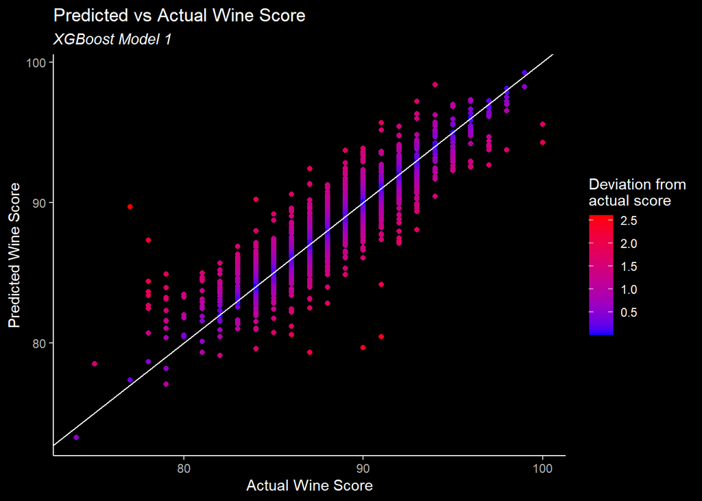

```r
# Martin Barron Graph Code

plot_data <- cbind.data.frame(actual, predicted)

plot_data$col <- log(abs(actual - predicted) + 1)

winebeast_plot <- ggplot(plot_data[actual > 60,], aes(x = actual, y = predicted, color = col)) + # removing outlier score of 60
  geom_point() +
  geom_abline(intercept = 0, slope = 1) +
  scale_color_gradient(low = "blue", high = "red") +
  dark_theme_bw() +
  theme(axis.line = element_line(colour = "white"),
        panel.grid.major = element_blank(),
        panel.grid.minor = element_blank(),
        panel.border = element_blank(),
        panel.background = element_blank(),
        plot.subtitle = element_text(face = "italic")) +
  labs(x = "Actual Wine Score", y = "Predicted Wine Score",
       title = "Predicted vs Actual Wine Score",
       subtitle = "XGBoost Model 1",
       color = "Deviation from\nactual score")

winebeast_plot
```

# Primary Tuning of XGBoost

## Check number of itterations in model

```r
set.seed(1984)
wine_amount <- xgb.cv(data = wtrain,
              nfold = 5,
               eta = 0.1,
               nrounds = 2000,
               early_stopping_rounds = 50,
               verbose = 1,
               nthread = 11,
               print_every_n = 20)
```

### Best itteration count is 756, 1000 will be a realistic iterations number for final XGBoost.

## Heat Map Loop

```r
# Tuning Loop - Martin Barron contribution.
# Be Careful - This can take a very long time to run
max_depth_vals <- c(3, 5, 7, 10, 15) # Create vector of max depth values
min_child_weight <- c(1,3,5,7, 10, 15) # Create vector of min child values

# Expand grid of parameter values
wcv_params <- expand.grid(max_depth_vals, min_child_weight)
names(wcv_params) <- c("max_depth", "min_child_weight")
# Create results vector
rmse_vec <- rep(NA, nrow(wcv_params))
# Loop through results
for(i in 1:nrow(wcv_params)){
  set.seed(1984)
  bst_tune <- xgb.cv(data = wtrain, # Set training data

              nfold = 5, # Use 5 fold cross-validation

              eta = 0.1, # Set learning rate
              max.depth = wcv_params$max_depth[i], # Set max depth
              min_child_weight = wcv_params$min_child_weight[i], # Set minimum number of samples in node to split


              nrounds = 500, # Set number of rounds
              early_stopping_rounds = 50, # Set number of rounds to stop at if there is no im
              verbose = 1, # 1 - Prints out fit
              nthread = 11, # Set number of parallel threads
              print_every_n = 20) # Prints out result every 20th iteration

  rmse_vec[i] <- bst_tune$evaluation_log$test_rmse_mean[bst_tune$best_ntreelimit]
}
```

## Heat Plot of Tuning

```r
# Martin Baron ggplot code
# Join results in dataset
res_db <- cbind.data.frame(wcv_params, rmse_vec)
names(res_db)[3] <- c("rmse")
res_db$max_depth <- as.factor(res_db$max_depth) # Convert tree number to factor for plotting
res_db$min_child_weight <- as.factor(res_db$min_child_weight) # Convert node size to factor for plotting
# Print RMSE heatmap
wine_heat <- ggplot(res_db, aes(y = max_depth, x = min_child_weight, fill = rmse)) + # set aesthetics
  geom_tile() + # Use geom_tile for heatmap
  theme_bw() + # Set theme
  scale_fill_gradient2(low = "blue", # Choose low color
    mid = "white", # Choose mid color
    high = "red", # Choose high color
    midpoint =mean(res_db$rmse), # Choose mid point
    space = "Lab",
    na.value ="grey", # Choose NA value
    guide = "colourbar", # Set color bar
    aesthetics = "fill") + # Select aesthetics to apply
  labs(x = "Minimum Child Weight", y = "Max Depth", fill = "RMSE") # Set labels

save(wine_heat, file = './RData/wine_heat.RData')
```

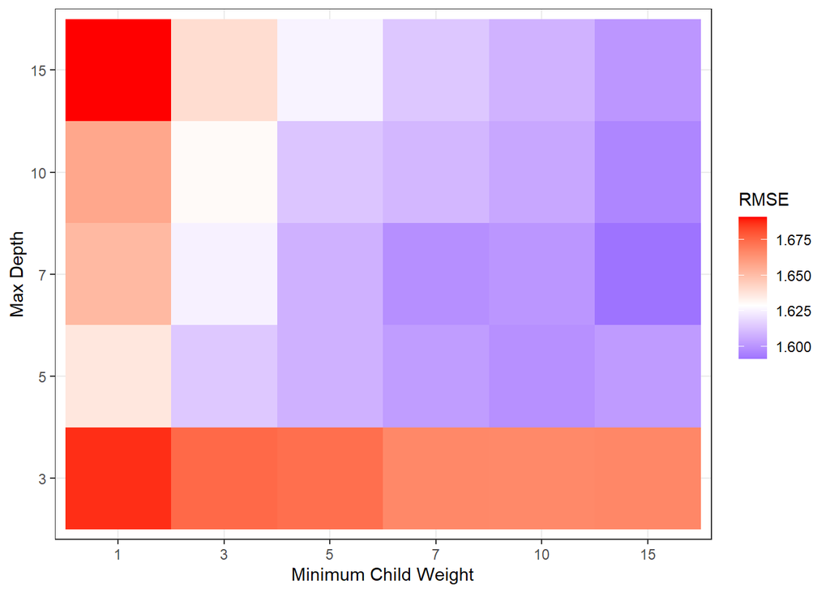

```r
load('./RData/wine_heat.RData')

wine_heat # Generate plot
```

### Max Depth Tuning Note

After additional examination of this heat plot, we had decided to change the max.depth setting from 15 to 7 in our new runs. However, we are not going to be re-running SHAP or the explainer at the end of this document. Any differences in RMSE or results will be highlighted in each section. Because of this change, we also will run through multiple etas using the new max.depth in order to ensure the best results.

## Combining Multiple etas for Optimal eta

### .1 eta Run

```r
set.seed(1984)
wine_eta1 <- xgb.cv(data = wtrain, # Set training data

              nfold = 5, # Use 5 fold cross-validation

              eta = 0.1, # Set learning rate
              max.depth = 7, # Set max depth
              min_child_weight = 15, # Set minimum number of samples in node to split
              gamma = 0, # Set minimum loss reduction for split
              subsample = 0.9, # Set proportion of training data to use in tree
              colsample_bytree =  0.9, # Set number of variables to use in each tree

              nrounds = 1000, # Set number of rounds
              early_stopping_rounds = 20, # Set number of rounds to stop at if there is no improvement

              verbose = 1, # 1 - Prints out fit
              nthread = 11, # Set number of parallel threads
              print_every_n = 20) # Set evaluation metric to use
```

### .05 eta Run

```r
set.seed(1984)
wine_eta2 <- xgb.cv(data = wtrain, # Set training data

              nfold = 5, # Use 5 fold cross-validation

              eta = 0.05, # Set learning rate
              max.depth = 7, # Set max depth
              min_child_weight = 15, # Set minimum number of samples in node to split
              gamma = 0, # Set minimum loss reduction for split
              subsample = 0.9, # Set proportion of training data to use in tree
              colsample_bytree =  0.9, # Set number of variables to use in each tree

              nrounds = 1000, # Set number of rounds
              early_stopping_rounds = 20, # Set number of rounds to stop at if there is no improvement

              verbose = 1, # 1 - Prints out fit
              nthread = 11, # Set number of parallel threads
              print_every_n = 20)
```

### .01 eta Run

```r
set.seed(1984)
wine_eta3 <- xgb.cv(data = wtrain, # Set training data

              nfold = 5, # Use 5 fold cross-validation

              eta = 0.01, # Set learning rate
              max.depth = 7, # Set max depth
              min_child_weight = 15, # Set minimum number of samples in node to split
              gamma = 0, # Set minimum loss reduction for split
              subsample = 0.9, # Set proportion of training data to use in tree
              colsample_bytree =  0.9, # Set number of variables to use in each tree

              nrounds = 1000, # Set number of rounds
              early_stopping_rounds = 20, # Set number of rounds to stop at if there is no improvement

              verbose = 1, # 1 - Prints out fit
              nthread = 11, # Set number of parallel threads
              print_every_n = 20)
```

### .005 eta Run

```r
set.seed(1984)
wine_eta4 <- xgb.cv(data = wtrain, # Set training data

              nfold = 5, # Use 5 fold cross-validation

              eta = 0.005, # Set learning rate
              max.depth = 7, # Set max depth
              min_child_weight = 15, # Set minimum number of samples in node to split
              gamma = 0, # Set minimum loss reduction for split
              subsample = 0.9, # Set proportion of training data to use in tree
              colsample_bytree =  0.9, # Set number of variables to use in each tree

              nrounds = 1000, # Set number of rounds
              early_stopping_rounds = 20, # Set number of rounds to stop at if there is no improvement

              verbose = 1, # 1 - Prints out fit
              nthread = 11, # Set number of parallel threads
              print_every_n = 20)
```

### .001 eta Run

```r
set.seed(1984)
wine_eta5 <- xgb.cv(data = wtrain, # Set training data

              nfold = 5, # Use 5 fold cross-validation

              eta = 0.001, # Set learning rate
              max.depth = 7, # Set max depth
              min_child_weight = 15, # Set minimum number of samples in node to split
              gamma = 0, # Set minimum loss reduction for split
              subsample = 0.9, # Set proportion of training data to use in tree
              colsample_bytree =  0.9, # Set number of variables to use in each tree

              nrounds = 1000, # Set number of rounds
              early_stopping_rounds = 20, # Set number of rounds to stop at if there is no improvement

              verbose = 1, # 1 - Prints out fit
              nthread = 11, # Set number of parallel threads
              print_every_n = 20)
```

## Binding All etas for Graph

```r
# Extract results for model with eta = 0.3
pd1 <- cbind.data.frame(wine_eta1$evaluation_log[,c("iter", "test_rmse_mean")], rep(0.1, nrow(wine_eta1$evaluation_log)))
names(pd1)[3] <- "eta"
# Extract results for model with eta = 0.1
pd2 <- cbind.data.frame(wine_eta2$evaluation_log[,c("iter", "test_rmse_mean")], rep(0.05, nrow(wine_eta2$evaluation_log)))
names(pd2)[3] <- "eta"
# Extract results for model with eta = 0.05
pd3 <- cbind.data.frame(wine_eta3$evaluation_log[,c("iter", "test_rmse_mean")], rep(0.01, nrow(wine_eta3$evaluation_log)))
names(pd3)[3] <- "eta"
# Extract results for model with eta = 0.01
pd4 <- cbind.data.frame(wine_eta4$evaluation_log[,c("iter", "test_rmse_mean")], rep(0.005, nrow(wine_eta4$evaluation_log)))
names(pd4)[3] <- "eta"
# Extract results for model with eta = 0.005
pd5 <- cbind.data.frame(wine_eta5$evaluation_log[,c("iter", "test_rmse_mean")], rep(0.001, nrow(wine_eta5$evaluation_log)))
names(pd5)[3] <- "eta"
# Join datasets
eta_data <- rbind.data.frame(pd1, pd2, pd3, pd4, pd5)
# Converty ETA to factor
eta_data$eta <- as.factor(eta_data$eta)
```

## Plotting eta Runs

```r
eta_plot_NEW <- ggplot(eta_data, aes(x = iter, y = test_rmse_mean, color = eta))+
  geom_smooth(alpha = 0.5) +
  theme_bw() + # Set theme
  theme(panel.grid.major = element_blank(), # Remove grid
        panel.grid.minor = element_blank(), # Remove grid
        panel.border = element_blank(), # Remove grid
        panel.background = element_blank()) + # Remove grid
  labs(x = "Number of Trees", title = "Error Rate v Number of Trees (Max Depth = 7)",
       y = "Error Rate", color = "Learning \n Rate")  # Set labels

save(eta_plot_NEW, file = './RData/eta_plot_NEW.RData')
```

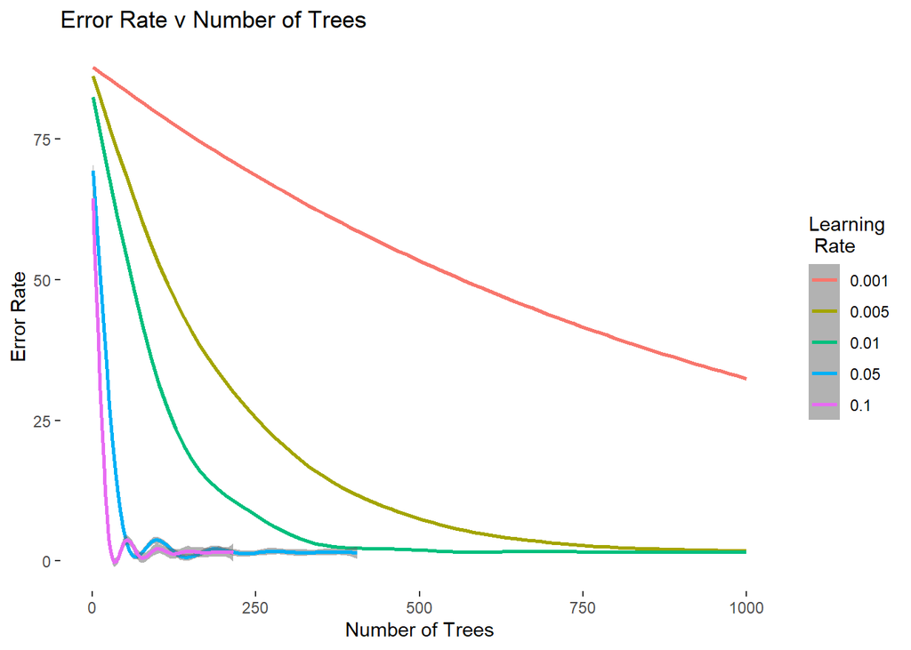

```r
load('./RData/eta_plot.RData')
load('./RData/eta_plot_NEW.RData')

eta_plot
```

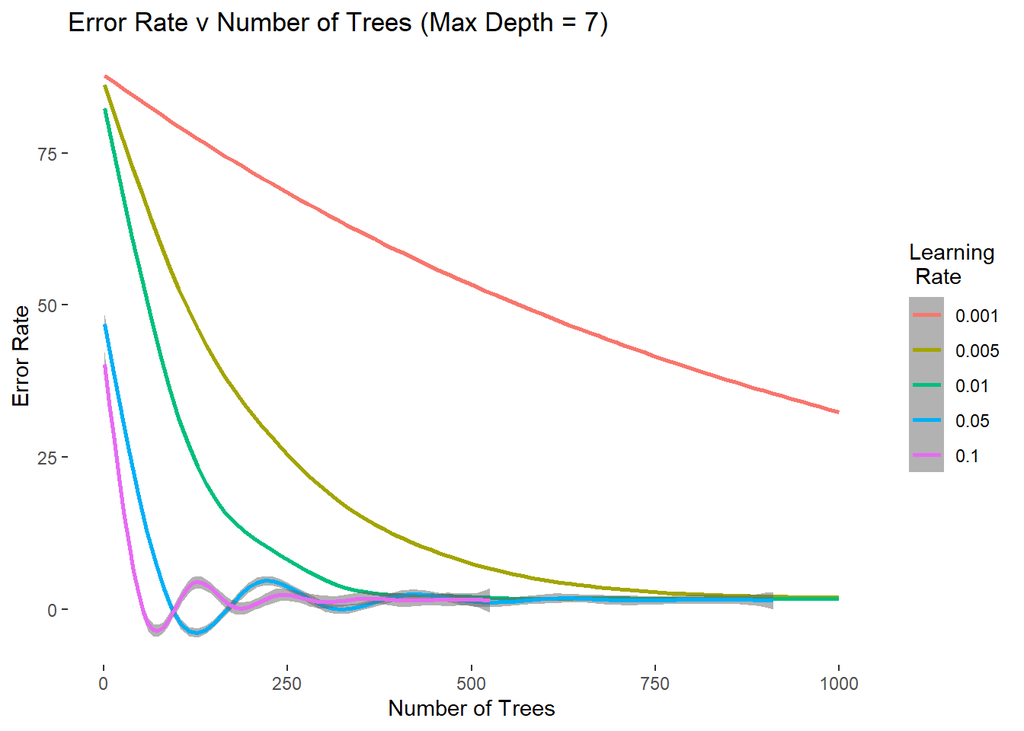

```r
eta_plot_NEW
```

Seeing the new plot with Max Depth set to 7, our decision for the learning rate maintains and we will stick with 0.01.

## Iteration Optimization

```r
# Optimization for eta at .01
set.seed(1984)

wine_it_light <- xgb.cv(data = wtrain,
              nfold = 5,
               eta = 0.01,
               nrounds = 8000,
               early_stopping_rounds = 50,
               verbose = 1,
               nthread = 11,
               print_every_n = 20)
```

### 7500 minimum on new learning rate

# Final XG Models and Visuals

## Optimal XGBoost with all Tuning Aspects

```r
# We initially had the max.depth set to 15 and
winebeast_1 <- xgboost(data = wtrain, # Use 5 fold cross-validation

              eta = 0.01, # Set learning rate
              max.depth = 7, # Set max depth
              min_child_weight = 15, # Set minimum number of samples in node to split

              nrounds = 8500, # Set number of rounds
              early_stopping_rounds = 20, # Set number of rounds to stop at if there is no improvement

              verbose = 1, # 1 - Prints out fit
              nthread = 11, # Set number of parallel threads
              print_every_n = 40)

save(winebeast_1, file = "./RData/winebeast_1.RData")
```

```r
load("./RData/winebeast_1.RData")

winebeast_1_preds <- predict(winebeast_1, wtrain)

winebeast_1_preds1 <- predict(winebeast_1, wtest)

rmse(actual, winebeast_1_preds1)
```

```
## [1] 1.605214
```

### Original RMSE: 1.672438 (Max Depth = 15)

### New RMSE: 1.605214 (Max Depth = 7)

## XGBoost with no Price

### Create No Price Data Frame

```r
non_price <-  noprice_wine_fixed[,-4]

np_XG <- non_price

np_XG[,c(2,4:619)] <-  lapply(np_XG[,c(2,4:619)], as.numeric)
```

### New Stratisize Split for Non-Price Data Frame

```r
set.seed(1984)

nonpric_split <-  stratified(np_XG, c('Score'), .80,bothSets = TRUE)

np_train_strat <- nonpric_split[[1]]
np_test_strat <- nonpric_split[[2]]
```

### New XGboost Groups for No Price

```r
# Create train matrix
nptrain <- xgb.DMatrix(data = as.matrix(np_train_strat[,c(2,4:619)]), label = as.numeric(np_train_strat$Score))
# Create test matrix
nptest <- xgb.DMatrix(data = as.matrix(np_test_strat[, c(2, 4:619)]), label = as.numeric(np_test_strat$Score))
```

## Running the XGboost Without the Price Variable.

```r
wine_noprice <- xgboost(data = nptrain,
              eta = 0.01, # Set learning rate
              max.depth = 7, # Set max depth
              min_child_weight = 15, # Set minimum number of samples in node to split
              nrounds = 8500, # Set number of rounds
              early_stopping_rounds = 20, # Set number of rounds to stop at if there is no improvement
              verbose = 1, # 1 - Prints out fit
              nthread = 11, # Set number of parallel threads
              print_every_n = 40)

save(wine_noprice, file = "./RData/wine_noprice.RData")
```

```r
load("./RData/wine_noprice.RData")

wine_noprice_preds <- predict(wine_noprice, nptrain)

wine_noprice_pred1 <- predict(wine_noprice, nptest)

rmse(np_test_strat$Score, wine_noprice_pred1)
```

```
## [1] 1.728415
```

# Original RMSE: 1.775378 (Max Depth = 15)

# New RMSE: 1.728415 (Max Depth = 7)

# Results for XGBoost

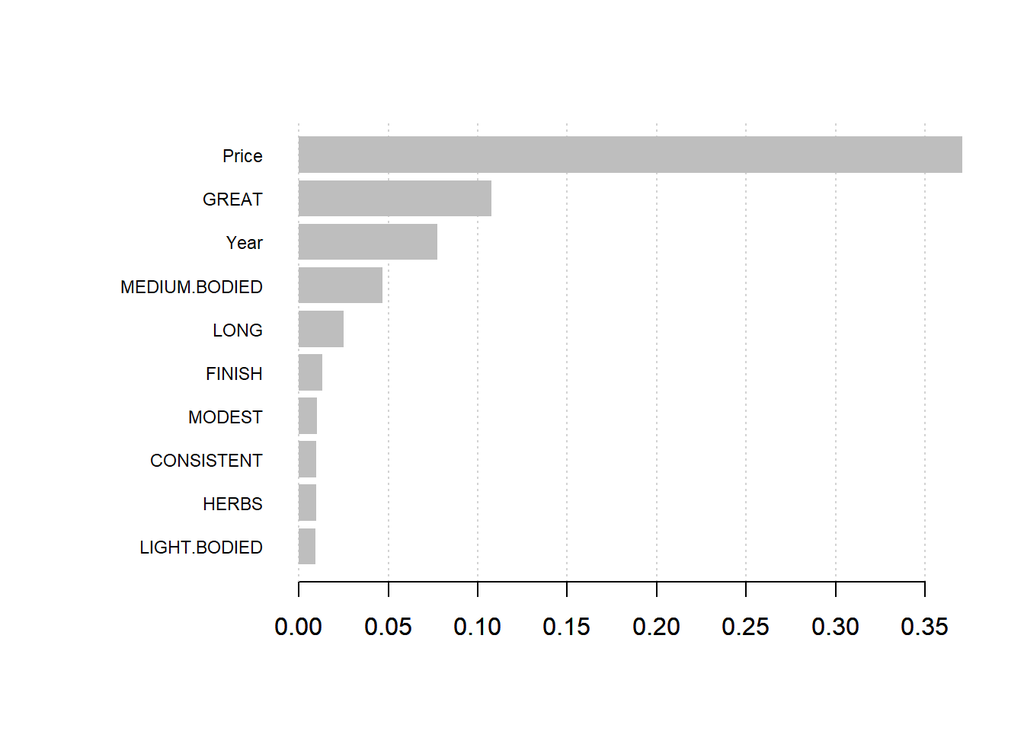

```r
# Extract importance
fullxg_mat <- xgb.importance(model = winebeast_1)
# Plot importance (top 10 variables)
xgb.plot.importance(fullxg_mat, top_n = 10)
```

## Top attributes for No Price XG

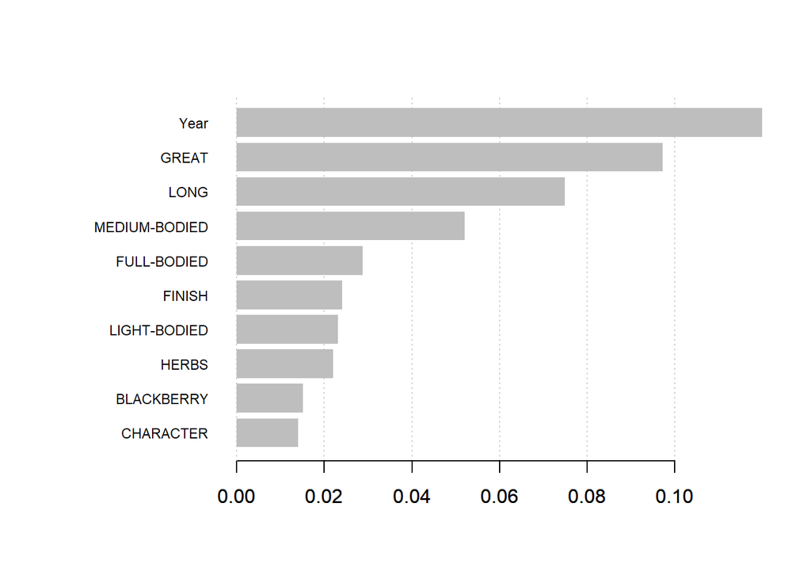

```r
# Extract importance
npxg_mat <- xgb.importance(model = wine_noprice)
# Plot importance (top 10 variables)
xgb.plot.importance(npxg_mat, top_n = 10)
```

## Graph of Full XG

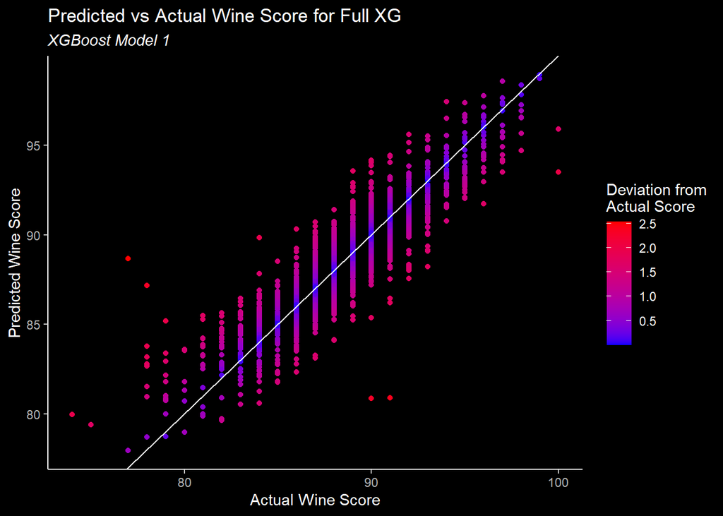

```r
act_wine_full <- test_strat$Score

pred_wine_full <- winebeast_1_preds1


wine_full_data <- cbind.data.frame(act_wine_full, pred_wine_full)
wine_full_data$col <- log(abs(act_wine_full - pred_wine_full) + 1)
wine_full_plot <- ggplot(wine_full_data[act_wine_full > 60,], aes(x = act_wine_full, y = pred_wine_full, color = col)) + ## removing outlier score of 60
  geom_point() +
  geom_abline(intercept = 0, slope = 1) +
  scale_color_gradient(low = "blue", high = "red") +
  dark_theme_bw() +
  theme(axis.line = element_line(colour = "white"),
        panel.grid.major = element_blank(),
        panel.grid.minor = element_blank(),
        panel.border = element_blank(),
        panel.background = element_blank(),
        plot.subtitle = element_text(face = "italic")) +
  labs(x = "Actual Wine Score", y = "Predicted Wine Score",
       title = "Predicted vs Actual Wine Score for Full XG",
       subtitle = "XGBoost Model 1",
       color = "Deviation from\nActual Score")
wine_full_plot
```

## Graph of No Price XG

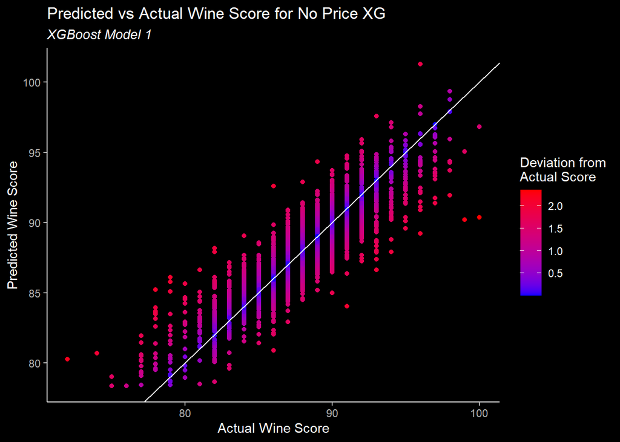

```r
act_wine_np <- np_test_strat$Score

pred_wine_np <- wine_noprice_pred1
#wine_np_data <- cbind.data.frame(act_wine_np, pred_wine_full)
wine_np_data <- cbind.data.frame(act_wine_np, pred_wine_np)
#wine_np_data$col <- log(abs(act_wine_np - pred_wine_full) + 1)
wine_np_data$col <- log(abs(act_wine_np - pred_wine_np) + 1)
wine_np_plot <- ggplot(wine_np_data[act_wine_np > 60,], aes(x = act_wine_np, y = pred_wine_np, color = col)) + ## removing outlier score of 60
  geom_point() +
  geom_abline(intercept = 0, slope = 1) +
  scale_color_gradient(low = "blue", high = "red") +
  dark_theme_bw() +
  theme(axis.line = element_line(colour = "white"),
        panel.grid.major = element_blank(),
        panel.grid.minor = element_blank(),
        panel.border = element_blank(),
        panel.background = element_blank(),
        plot.subtitle = element_text(face = "italic")) +
  labs(x = "Actual Wine Score", y = "Predicted Wine Score",
       title = "Predicted vs Actual Wine Score for No Price XG",
       subtitle = "XGBoost Model 1",
       color = "Deviation from\nActual Score")
wine_np_plot
```

## SHAP and XGBoost Explainer

This section was ran prior to the change of Max Depth, all of these graphs are using the model’s that had the Max Depth of 15.

For the sake of time we chose not to re-run this section.

## SHAP Code Full XG 1 of 3

```r
XG_exp = buildExplainer(winebeast_1, wtrain, type = "regression", base_score = 0.5, trees_idx = NULL)

save(XG_exp, file = "XG_exp_shap.RData")
```

```r
load('./RData/XG_exp_shap.RData')
```

## SHAP Code FUll XG 2 of 3

```r
pred_full_breakdown = explainPredictions(winebeast_1, XG_exp, wtest) # Breakdown predictions

save(pred_full_breakdown, file = "SHAP_full_breakdown_fullXG.RData")
```

```r
load('./RData/SHAP_full_breakdown_fullXG.RData')

pred_full_breakdown
```

## SHAP Code FUll XG 3 of 3

```r
waterfall_shap_fullXG = showWaterfall(winebeast_1, XG_exp, wtrain, as.matrix(test_strat[, c(2, 4:620)]) ,1441, type = "regression", threshold = 0.07)

save(waterfall_shap_fullXG, file = "waterfall_shap_fullXG.RData")
```

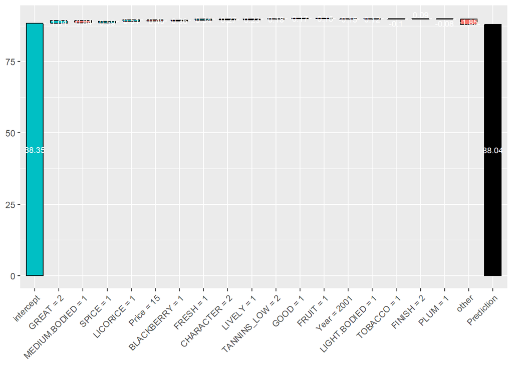

```r
load('./RData/waterfall_shap_fullXG.RData')

waterfall_shap_fullXG
```

## SHAP code noPrice XG 1 of 3

```r
npXG_exp = buildExplainer(wine_noprice, nptrain, type = "regression", base_score = 0.5, trees_idx = NULL)

save(npXG_exp, file = "XG_exp_shap_NP.RData")
```

```r
load('./RData/shap_np_xg_exp.RData')
```

## SHAP code noPrice 2 of 3

```r
pred_np_breakdown = explainPredictions(wine_noprice, npXG_exp, nptest)

save(pred_np_breakdown, file = "SHAP_np_breakdown.RData")
```

```r
load('./RData/SHAP_np_breakdown.RData')

pred_np_breakdown
```

## SHAP code noPrice 3 of 3

```r
waterfall_shap_np = showWaterfall(wine_noprice, npXG_exp, nptrain, as.matrix(np_test_strat[, c(2, 4:619)]) ,1441, type = "regression", threshold = 0.07)

save(waterfall_shap_np, file = "waterfall_shap_np.RData")
```

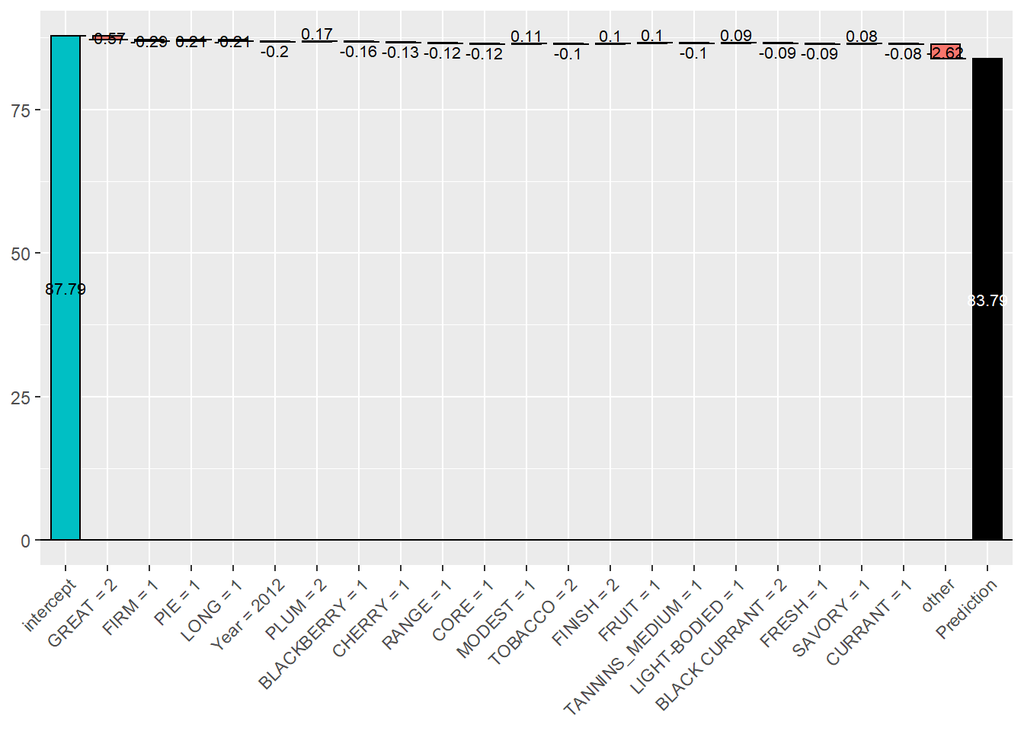

```r
load('./RData/waterfall_shap_np.RData')

waterfall_shap_np
```

# SHAP Scores

## For the price model

```r
shap_result <- shap.score.rank(xgb_model = winebeast_1,
                               X_train = as.matrix(train_strat[,c(2,4:620)]),
                               shap_approx = F)

save(shap_result, file = "shap_results.RData")
```

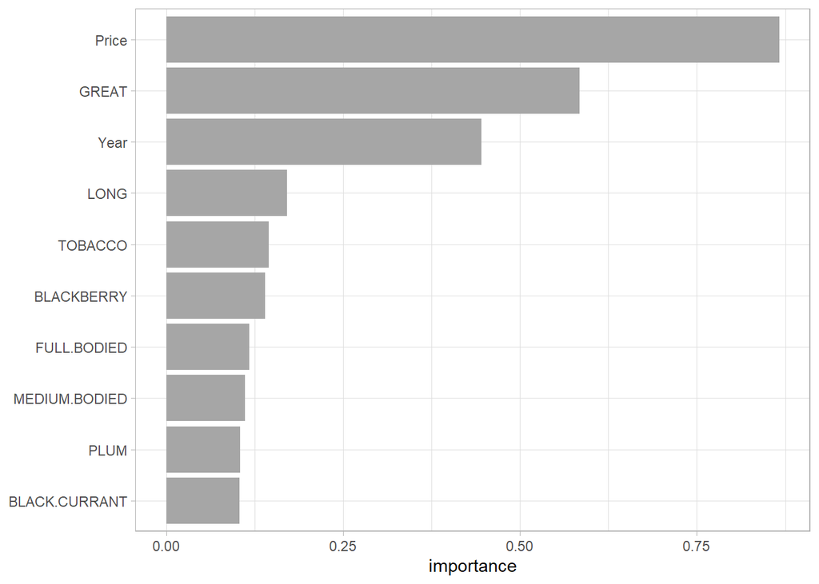

```r
load('./RData/shap_results.RData')

var_importance(shap_result, top_n=10)
```

```r
shap_long = shap.prep(shap = shap_result,
                      X_train = as.matrix(train_strat[,c(2,4:620)]),
                      top_n = 10)

save(shap_long, file = "shap_long.RData")
```

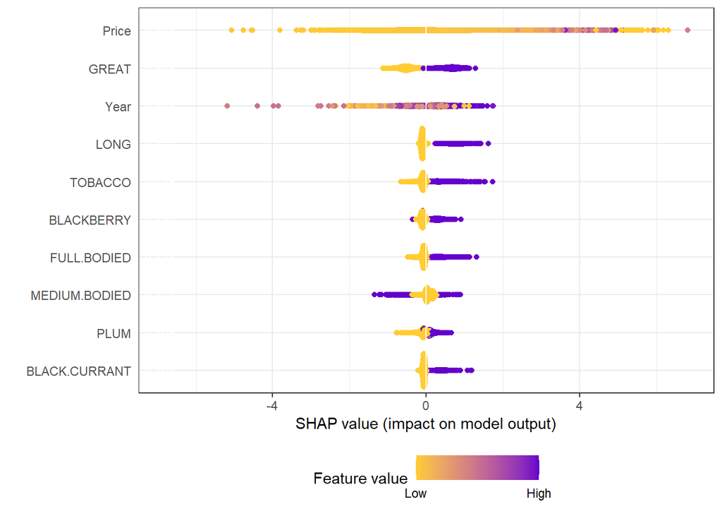

```r
load('./RData/shap_long.RData')

plot.shap.summary(data_long = shap_long)
```

## For the no-price model

```r
shap_result_np <- shap.score.rank(xgb_model = wine_noprice,
                                  X_train = as.matrix(np_train_strat[,c(2,4:619)]),
                                  shap_approx = F)

save(shap_result_np, file = "shap_results_np.RData")
```

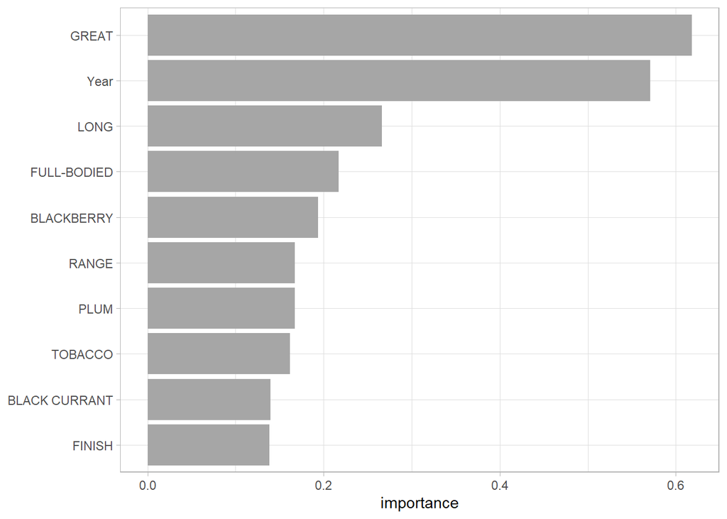

```r
load('./RData/shap_results_np.RData')

var_importance(shap_result_np, top_n = 10)
```

```r
shap_long_np = shap.prep(shap = shap_result_np,
                         X_train = as.matrix(np_train_strat[,c(2,4:619)]),
                         top_n = 10)

save(shap_long_np, file = "shap_long_np.RData")
```

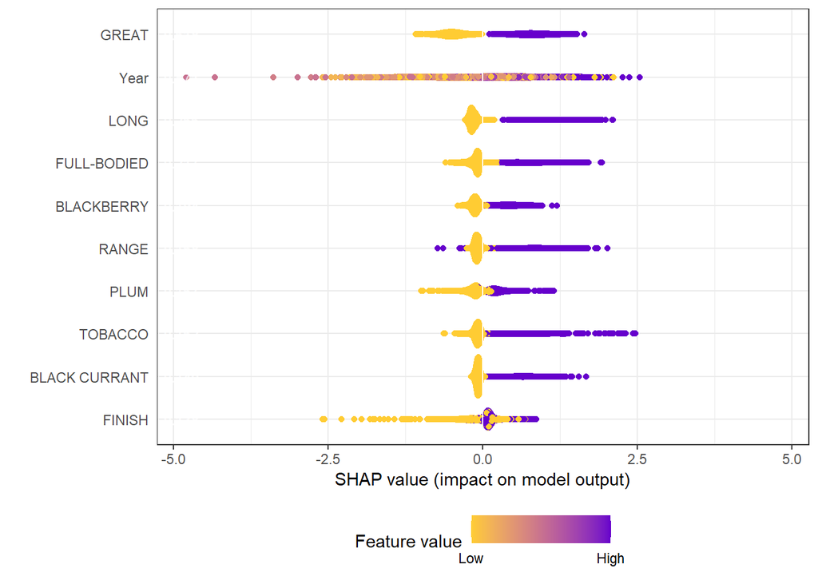

```r
load("./RData/shap_long_np.RData")

plot.shap.summary(data_long = shap_long_np)
```